## Weather Impact on Population Health and Economic Consequences

## Synopsis

This document summarizes exploration of storm and severe weather event data from the National Weather Service between 1950 and 2011 to United States citizens. The analysis ranks events that are most harmful with respect to population health and those that have the greatest economic consequences.

Looking at events that are most harmful with respect to population health, tornados overwhelming cause the most damage with 96,979 people affected. This is number is over 10 times more than the second most harmful event, excessive heat, with 8,428 people affected. Completing the top 5, next comes TSTM Wind (7461), flood (7259), and finally lightning (6046).

As for events causing the greatest economic consequences, floods are the most devestating causing over $150 billion. This amount is over double the next most costly event, hurricane/typhoon, costing over $70 billion. Completing the top 5 are tornado (over $57 billion), storm surge (over $43 billion), and hail (over $18 billion).

### Data Processing

```r
setwd("~/Documents/r/coursera/5 Reproducible Research/assignment2")

if (!file.exists("repdata%2Fdata%2FStormData.csv.bz2")) {
    fileUrl <- "https://d396qusza40orc.cloudfront.net/repdata%2Fdata%2FStormData.csv.bz2"
    download.file(fileUrl, destfile = "repdata%2Fdata%2FStormData.csv.bz2", method = "curl")
}

storm <- read.csv("repdata%2Fdata%2FStormData.csv.bz2")
```

### Data Transformations

```r
library(dplyr)
#Attempt to normalize EVTYPE values
#Initial number of EVTYPE groupings
nrow(storm %>%
    group_by(EVTYPE) %>%
    summarize(counter = sum(STATE__)))
```

```
## [1] 985
```

```r
#Convert lower case EVTYPE values to upper case
storm$EVTYPE <- toupper(storm$EVTYPE)
nrow(storm %>%
    group_by(EVTYPE) %>%
    summarize(counter = sum(STATE__)))
```

```
## [1] 898
```

```r
#Convert plural EVTYPE values to singular
storm$EVTYPE <- sub("S$", "", storm$EVTYPE)
nrow(storm %>%
    group_by(EVTYPE) %>%
    summarize(counter = sum(STATE__)))
```

```
## [1] 855
```

```r
#Add new column HARMFUL to store accumulated FATALITIES and INJURIES
storm$HARMFUL <- storm$FATALITIES + storm$INJURIES

#Function applyDamageExp takes damage amount and damage exponent as input to determine actual damage amount
applyDamageExp <- function (x, y) {
    if(x == "K") as.numeric(y) * 1000
    else if(x == "M") as.numeric(y) * 1000000
    else if (x == "B") as.numeric(y) * 1000000000
    else 0
}

#Add new column PROPDMGAMT to store actual property damage amount
storm$PROPDMGAMT <- apply(storm[, c('PROPDMGEXP', 'PROPDMG')], 1,
                          function(x) applyDamageExp(x['PROPDMGEXP'], x['PROPDMG']))

#Add new column CROPDMGAMT to store actual crop damage amount
storm$CROPDMGAMT <- apply(storm[, c('CROPDMGEXP', 'CROPDMG')], 1,
                          function(x) applyDamageExp(x['CROPDMGEXP'], x['CROPDMG']))

#Add new column DAMAGEAMT to store accumulated PROPDMGAMT and CROPDMGAMT
storm$DAMAGEAMT <- storm$PROPDMGAMT + storm$CROPDMGAMT
```

### Results

```r
library(ggplot2)

#events that are most harmful with respect to population health
harmfulDF <- storm %>%
    group_by(EVTYPE) %>%
    summarize(counter = sum(HARMFUL)) %>%
    filter(counter > 0) %>%
    arrange(desc(counter))

harmfulDF
```

```
## # A tibble: 192 x 2
##               EVTYPE counter
##                <chr>   <dbl>
##  1           TORNADO   96979
##  2    EXCESSIVE HEAT    8428
##  3         TSTM WIND    7461
##  4             FLOOD    7259
##  5         LIGHTNING    6046
##  6              HEAT    3037
##  7       FLASH FLOOD    2757
##  8 THUNDERSTORM WIND    2593
##  9         ICE STORM    2064
## 10         HIGH WIND    1722
## # ... with 182 more rows
```

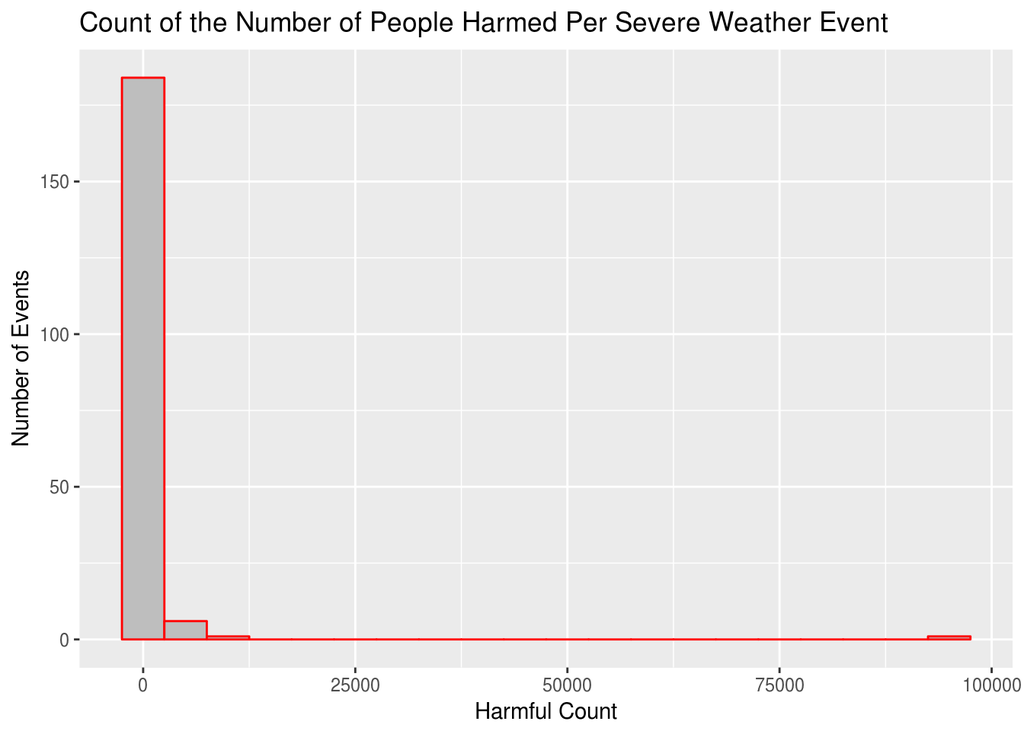

```r
ggplot(harmfulDF) +
    geom_histogram(aes(x=counter), binwidth = 5000, col="red", fill="grey") +
    ggtitle("Count of the Number of People Harmed Per Severe Weather Event") +
    xlab("Harmful Count") +
    ylab("Number of Events")
```

```r
#events that have the greatest economic consequences
damageDF <- storm %>%
    group_by(EVTYPE) %>%
    summarize(amt = sum(DAMAGEAMT)) %>%
    filter(amt > 0) %>%
    arrange(desc(amt))

damageDF
```

```
## # A tibble: 369 x 2
##               EVTYPE          amt
##                <chr>        <dbl>
##  1             FLOOD 150325728250
##  2 HURRICANE/TYPHOON  71913712800
##  3           TORNADO  57340613590
##  4       STORM SURGE  43323541000
##  5              HAIL  18752904170
##  6       FLASH FLOOD  17570857110
##  7           DROUGHT  15018672000
##  8         HURRICANE  14610229010
##  9       RIVER FLOOD  10148404500
## 10         ICE STORM   8967041310
## # ... with 359 more rows
```

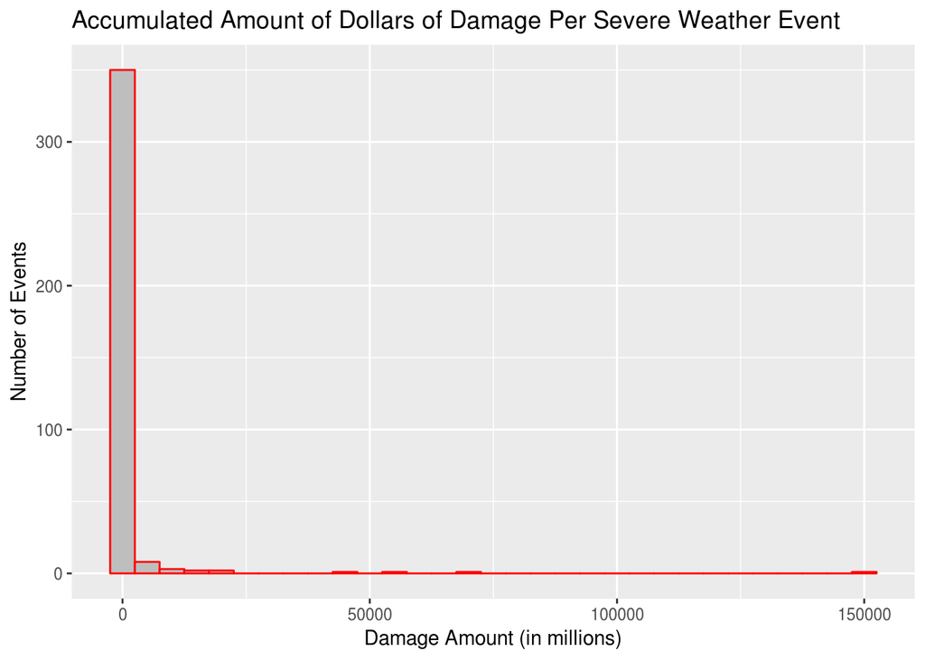

```r
ggplot(damageDF) +
    geom_histogram(aes(x=amt/1000000), binwidth = 5000, col="red", fill="grey") +
    ggtitle("Accumulated Amount of Dollars of Damage Per Severe Weather Event") +
    xlab("Damage Amount (in millions)") +
    ylab("Number of Events")
```